# NYPD Shooting Incidents

E.S.

2024-04-10

## Step 1: Start an Rmd Document

**Start an Rmd document that describes and imports the shooting project dataset in a reproducible manner.**

> We will be using the City of New York’s data on shooting incidents from 2006 through 2022.  
> As described by its webpage on [data.gov](https://catalog.data.gov/dataset/nypd-shooting-incident-data-historic): *“This data is manually extracted every quarter and reviewed by the Office of Management Analysis and Planning before being posted on the NYPD website. Each record represents a shooting incident in NYC and includes information about the event, the location and time of occurrence. In addition, information related to suspect and victim demographics is also included.”*

> Ultimately, we will examine the relationship between average monthly temperature and monthly shootings in the Bronx in 2021.

```r
# Load the tidyverse, lubridate, dplyr, & ggplot2 packages
library(tidyverse)
library(lubridate)
library(dplyr)
library(ggplot2)

# Read in .csv dataset of NYPD shootings
url_in <- "https://data.cityofnewyork.us/api/views/833y-fsy8/rows.csv?accessType=DOWNLOAD"
NYC_shootings <- read_csv(url_in)
```

## Step 2: Tidy and Transform Your Data

**Add to your Rmd document a summary of the data and clean up your dataset by changing appropriate variables to factor and date types and getting rid of any columns not needed. Show the summary of your data to be sure there is no missing data. If there is missing data, describe how you plan to handle it.**

```r
# View summary of data
summary(NYC_shootings)
```

```
##   INCIDENT_KEY        OCCUR_DATE         OCCUR_TIME           BORO
##  Min.   :  9953245   Length:27312       Length:27312      Length:27312
##  1st Qu.: 63860880   Class :character   Class1:hms        Class :character
##  Median : 90372218   Mode  :character   Class2:difftime   Mode  :character
##  Mean   :120860536                      Mode  :numeric
##  3rd Qu.:188810230
##  Max.   :261190187
##
##  LOC_OF_OCCUR_DESC     PRECINCT      JURISDICTION_CODE LOC_CLASSFCTN_DESC
##  Length:27312       Min.   :  1.00   Min.   :0.0000    Length:27312
##  Class :character   1st Qu.: 44.00   1st Qu.:0.0000    Class :character
##  Mode  :character   Median : 68.00   Median :0.0000    Mode  :character
##                     Mean   : 65.64   Mean   :0.3269
##                     3rd Qu.: 81.00   3rd Qu.:0.0000
##                     Max.   :123.00   Max.   :2.0000
##                                      NA's   :2
##  LOCATION_DESC      STATISTICAL_MURDER_FLAG PERP_AGE_GROUP
##  Length:27312       Mode :logical           Length:27312
##  Class :character   FALSE:22046             Class :character
##  Mode  :character   TRUE :5266              Mode  :character
##
##
##
##
##    PERP_SEX          PERP_RACE         VIC_AGE_GROUP        VIC_SEX
##  Length:27312       Length:27312       Length:27312       Length:27312
##  Class :character   Class :character   Class :character   Class :character
##  Mode  :character   Mode  :character   Mode  :character   Mode  :character
##
##
##
##
##    VIC_RACE           X_COORD_CD        Y_COORD_CD        Latitude
##  Length:27312       Min.   : 914928   Min.   :125757   Min.   :40.51
##  Class :character   1st Qu.:1000028   1st Qu.:182834   1st Qu.:40.67
##  Mode  :character   Median :1007731   Median :194487   Median :40.70
##                     Mean   :1009449   Mean   :208127   Mean   :40.74
##                     3rd Qu.:1016838   3rd Qu.:239518   3rd Qu.:40.82
##                     Max.   :1066815   Max.   :271128   Max.   :40.91
##                                                        NA's   :10
##    Longitude        Lon_Lat
##  Min.   :-74.25   Length:27312
##  1st Qu.:-73.94   Class :character
##  Median :-73.92   Mode  :character
##  Mean   :-73.91
##  3rd Qu.:-73.88
##  Max.   :-73.70
##  NA's   :10
```

> After glancing over the initial summary, let’s look at the borough and date of occurrence columns, specifically. Columns related to time/precinct/demographics/location coordinates can be removed. We will also add OCCUR_MONTH and OCCUR_YEAR columns in order to interact with the date of occurrence data in different ways.

```r
# Remove variables that are not of interest
NYC_shootings <- NYC_shootings %>%
  select(-c(OCCUR_TIME, LOC_OF_OCCUR_DESC, PRECINCT, JURISDICTION_CODE, LOC_CLASSFCTN_DESC, LOCATION_DESC, STATISTICAL_MURDER_FLAG, PERP_AGE_GROUP, PERP_SEX, PERP_RACE, VIC_AGE_GROUP, VIC_SEX, VIC_RACE, X_COORD_CD, Y_COORD_CD, Latitude, Longitude, Lon_Lat))

# Reformat OCCUR_DATE
NYC_shootings$OCCUR_DATE <- mdy(NYC_shootings$OCCUR_DATE)

# Create OCCUR_YEAR & OCCUR_MONTH
NYC_shootings <- NYC_shootings %>%
  mutate(OCCUR_YEAR = c(year(NYC_shootings$OCCUR_DATE))) %>%
  mutate(OCCUR_MONTH = c(month(NYC_shootings$OCCUR_DATE)))

# View new summary of data
summary(NYC_shootings)
```

```
##   INCIDENT_KEY         OCCUR_DATE             BORO             OCCUR_YEAR
##  Min.   :  9953245   Min.   :2006-01-01   Length:27312       Min.   :2006
##  1st Qu.: 63860880   1st Qu.:2009-07-18   Class :character   1st Qu.:2009
##  Median : 90372218   Median :2013-04-29   Mode  :character   Median :2013
##  Mean   :120860536   Mean   :2014-01-06                      Mean   :2013
##  3rd Qu.:188810230   3rd Qu.:2018-10-15                      3rd Qu.:2018
##  Max.   :261190187   Max.   :2022-12-31                      Max.   :2022
##   OCCUR_MONTH
##  Min.   : 1.000
##  1st Qu.: 5.000
##  Median : 7.000
##  Mean   : 6.825
##  3rd Qu.: 9.000
##  Max.   :12.000
```

```r
# Check for any null values (Output of "0" means no missing data)
sum(is.na(NYC_shootings))
```

```
## [1] 0
```

## Step 3: Add Visualizations and Analysis

**Add at least two different visualizations & some analysis to your Rmd. Does this raise additional questions that you should investigate?**

> First, we should see what yearly shootings look like in the boroughs. A visualization could be useful in interpreting that data.

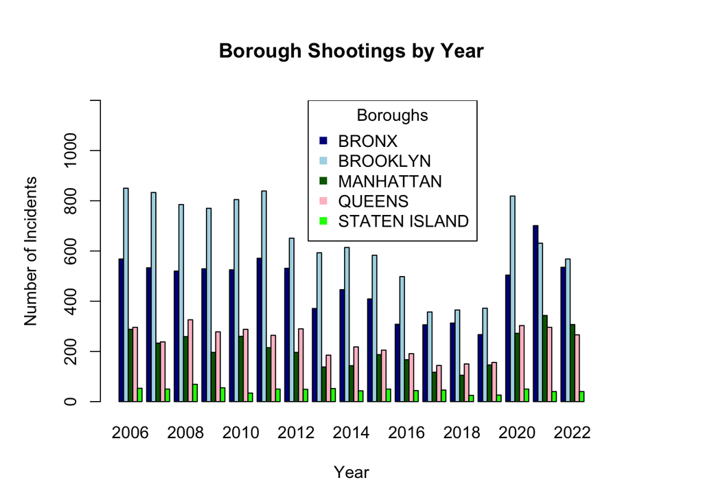

```r
# Create a grouped bar plot of yearly shootings by borough
Borough_Shootings_by_Year <- table(NYC_shootings$BORO, NYC_shootings$OCCUR_YEAR)

par(mar = c(5, 5, 5, 5))
barplot(Borough_Shootings_by_Year,
        main = "Borough Shootings by Year",
        xlab = "Year", ylab = "Number of Incidents", ylim = c(0, 1200),
        beside = TRUE,
        col=c("darkblue","lightblue","darkgreen","pink","green"))
legend("topright",
       inset = c(0.25, 0),
       title = "Boroughs", rownames(Borough_Shootings_by_Year), pch = 15,
       col = c("darkblue","lightblue","darkgreen","pink","green"))
```

> The number of shootings in each borough varies quite a bit. Staten Island, Queens, and Manhattan have relatively low numbers of shootings each year, while the Bronx and Brooklyn are at the top.
- Is the number of shootings influenced by the size/population of a borough?
- What role do socioeconomic factors play?
  - Demographics?
  - Poverty?
  - Access to guns?

> As we can see, Brooklyn is the borough that has the most shootings every year…except for 2021. That year the Bronx had the most shooting incidents. Let’s investigate that borough/year combination by creating a table of shootings in each month and plotting it.

```r
# Filter the shootings in 2021
NYC_shootings_2021<- NYC_shootings %>% filter(OCCUR_DATE >= '2021-01-01' & OCCUR_DATE <= '2021-12-31')

# Filter the 2021 shootings in the Bronx
Bronx_shootings_2021 <- NYC_shootings_2021 %>% filter(str_detect("BRONX", NYC_shootings_2021$BORO))

# Create a table of shootings by month number (1 = Jan, 2 = Feb, ..., 12 = Dec)
table(Bronx_shootings_2021$OCCUR_MONTH)
```

[output not shown]

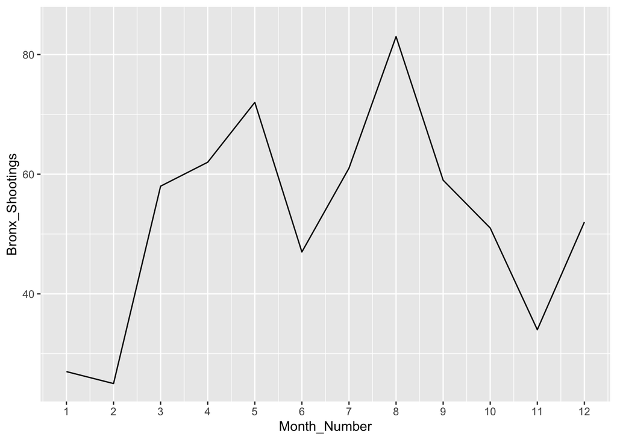

```r
# Create a line plot of the data from the table above
Month_Number <- 1:12
Bronx_Shootings <- c(27, 25, 58, 62, 72, 47, 61, 83, 59, 51, 34, 52)
data <- data.frame(Month_Number, Bronx_Shootings)

ggplot(data, aes(x=Month_Number, y=Bronx_Shootings)) +
  geom_line() +
  xlim(1, 12) +
  ylim(25, 85) +
  scale_x_continuous(breaks=1:12)
```

> The winter months tend to have a lower number of monthly shootings, while the summer months are on the higher end. Let’s investigate the relationship between monthly shootings and average monthly temperature.

> *Linked are the average monthly temperatures (Fahrenheit) for 2021 from the [National Weather Service](https://www.weather.gov/media/okx/Climate/CentralPark/monthlyannualtemp.pdf). (Central Park is located in Manhattan, but it is very close to the Bronx—especially in a meteorological sense, so it will work well for our purposes here.)*

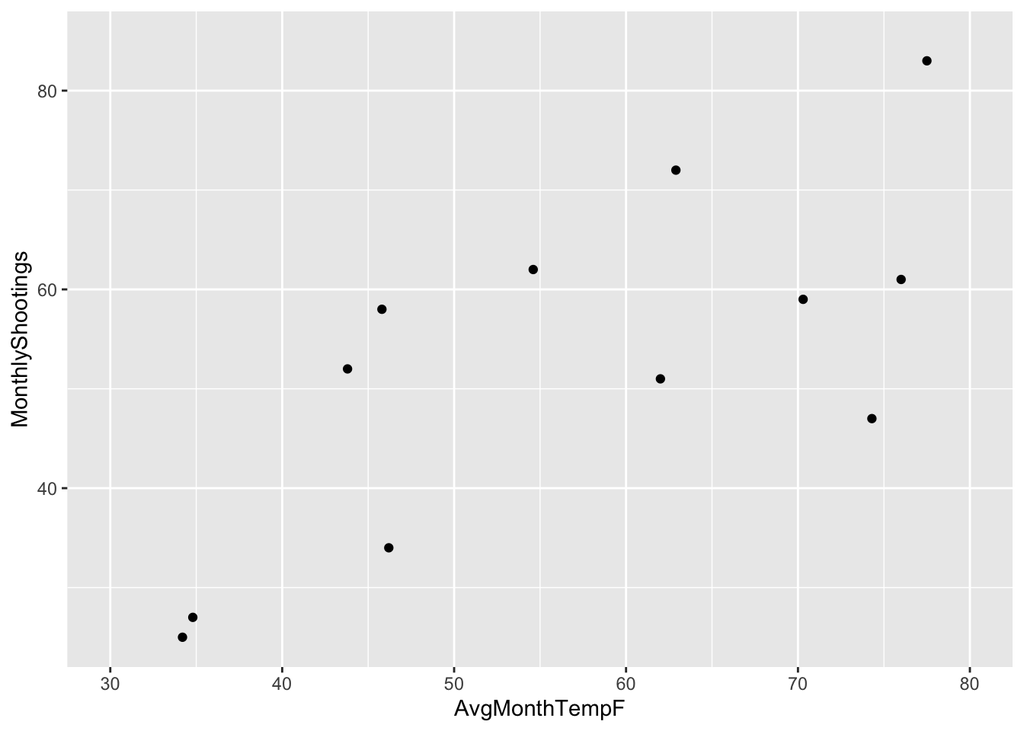

```r
# Create new data.frame incorporating temperature data
AvgMonthTempF <- c(34.8, 34.2, 45.8, 54.6, 62.9, 74.3, 76, 77.5, 70.3, 62, 46.2, 43.8)
MonthlyShootings <- c(27, 25, 58, 62, 72, 47, 61, 83, 59, 51, 34, 52)
Shootings_by_Temp <- data.frame(AvgMonthTempF, MonthlyShootings)

# Plot monthly Bronx shootings (2021) by average monthly temperature (2021, Fahrenheit)
ggplot(Shootings_by_Temp, aes(x=AvgMonthTempF, y=MonthlyShootings)) +
  geom_point() +
  xlim(30, 80) +
  ylim(25, 85)
```

> Based on this plot, it looks like there is a correlation between average monthly temperature and monthly shootings. A linear model will help determine if this correlation is statistically significant.

```r
mod <- lm(MonthlyShootings ~ AvgMonthTempF, data = Shootings_by_Temp)
summary(mod)
```

```
##
## Call:
## lm(formula = MonthlyShootings ~ AvgMonthTempF, data = Shootings_by_Temp)
##
## Residuals:
##     Min      1Q  Median      3Q     Max
## -19.526  -8.315  -5.008  11.901  14.591
##
## Coefficients:
##               Estimate Std. Error t value Pr(>|t|)
## (Intercept)     7.1023    14.0418   0.506  0.62396
## AvgMonthTempF   0.7998     0.2386   3.352  0.00734 **
## ---
## Signif. codes:  0 '***' 0.001 '**' 0.01 '*' 0.05 '.' 0.1 ' ' 1
##
## Residual standard error: 12.52 on 10 degrees of freedom
## Multiple R-squared:  0.5291, Adjusted R-squared:  0.482
## F-statistic: 11.23 on 1 and 10 DF,  p-value: 0.007343
```

> Looking at the p-value produced by the model, the correlation between average monthly temperature and monthly shootings is confirmed to be statistically significant. Let’s add the model predictions to the previous plot.

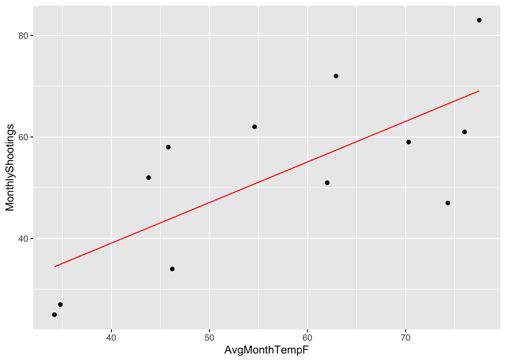

```r
#Plot the model predictions alongside the actual data
Shootings_by_Temp_w_Pred <- Shootings_by_Temp %>%
  mutate(Prediction = predict(mod))

Shootings_by_Temp_w_Pred %>% ggplot() +
  geom_point(aes(x = AvgMonthTempF, y = MonthlyShootings), color = "black") +
  geom_line(aes(x = AvgMonthTempF, y = Prediction), color = "red")
```

> This plot helps visualize the positive correlation between these variables. It also leads us to additional questions, such as:
- Does this correlation hold true for other years? For other boroughs?
- What other seasonal factors beyond temperature could play a role in the increase of shootings in warmer months?
  - Summer break from school?
  - More time spent outside?
  - A higher population in summertime? (more tourists, seasonal workers, etc.)

## Project Step 4: Add Bias Identification

**Write the conclusion to your project report and include any possible sources of bias. Be sure to identify what your personal bias might be and how you have mitigated that.**

> As stated above, there is a statistically significant correlation between the average monthly temperature and the number of shootings that occurred in a given month in the Bronx (in 2021). Personally, my existing assumption was that summers have more shootings than winter, so including a relevant model showing a statistically significant correlation helps to mitigate confirmation bias.